# Changes in the European Energy Market due the Russia-Ukraine War

Short and Long Term Impacts

Author

Gavin Ulrich, Byeonghun Kwon

Published

December 9, 2024

## Research Question

How has the European energy market been impacted by the end of Russian energy exports due to the Russian-Ukraine war? How has the market responded in both domestic production and international exports?

## Data Sources

#Eurostat

Eurostat is the statistics office of the EU and provides data on Europe through an official Eurostat website. They provide a large amount of data ranging across the EU, and contain a large amount of energy data. This data is being updated regularly, providing up to date data as recent as the current month. Eurostat is a reputable source and primary source, as this data is collected by and presented by the official EU. The data of Eurostat is reliable because the EU uses the data to make informed decisions. The data needs to be accurate in order to properly make decisions, so therefore it makes more sense for this data to be objective. Eurostat provided us with data based around the immediate impact, how household prices changed across the EU.

https://ec.europa.eu/eurostat/databrowser/view/nrg_pc_202/default/line?lang=en&category=nrg.nrg_price.nrg_pc

#Bruegel

Bruegel, which is an independent think tank focused around economics with a focus on and association with the EU. The group is openly independent and transparent, with a number of independent reviews. They are transparent about their funding and influences from outside interests. For these reasons we believe that they are a trustworthy and reliable source of information, as they clearly show they are interested in open research not political agendas. Their director Jeromin Zettelmeyer has a very impressive resume, with experience including the IMF and the German Federal Ministry. The rest of the team have similar experience working with major european banks and other reputable organisations. Brugel provided data for the EUs natural gas imports, breaking down how and from which nations the EU imports its natural gas.

https://www.bruegel.org/dataset/european-natural-gas-imports

#Ember

Ember is a global energy non-profit think tank with a focus on green renewable energy. The group is open about its mission to increase support for sustainable energy. They are open about their sponsors, and provide information about their employees. Ember is another reputable source, they are open about their goals and funding and offer ways to contact those who collected and presented the data. Green energy and renewable non-profits organizations do tend to have a bias towards supporting green energy, however they still provide accurate data as their goal is to accurately assess the state of the energy market. Ember was the source for domestic electricity production in the EU, both total and broken down by source. This data not only provides information on how much electricity is being produced domestically but also how the market is changing with the different sources of energy.

https://ember-energy.org/data/electricity-data-explorer/#dataset

##Role of Russia in the EU Energy Market

The European energy market was heavily dependent on Russian gas pipelines. On February 24 2022, Russia-Ukraine war began. Because of the war, gas transits through the major gas pipelines, Nord Stream, Turk stream, Ukraine and Yamal, were decreased or ended for different reasons. Before the war, generally gas transit was more than 2000 million cubic meters but after the war, it decreased to less than 1000 million cubic meters.

[figure not shown]

```r
route_combined %>% ggplot() +
    geom_area(aes(x = Week_Continuous, y = Gas_transit, fill = Route), size = 1) +
    scale_x_continuous(breaks = seq(0, 3 * 53, by = 53),
                       labels = c("2021", "2022", "2023", "2024")) +
    theme_minimal() +
    labs(title = "European Gas Transit from Russian Gas Pipelines",
        subtitle = "Gas Transit from 2021 to 2024",
         x = "Year",
         y = "Gas Transit (million cubic meters)",
        caption = "source : https://www.bruegel.org/dataset/european-natural-gas-imports")+
    geom_vline(xintercept = 53+25, col = 'grey60', size = 0.7) +
    scale_fill_manual(values = c(
        'lightblue', 'skyblue', 'royalblue', 'royalblue3'))+
    annotate('text', x = 53+33, y = 1000, hjust = 0,
             label = 'Week 30 in 2022',
             color = 'grey30')
```

##Immediate Impact

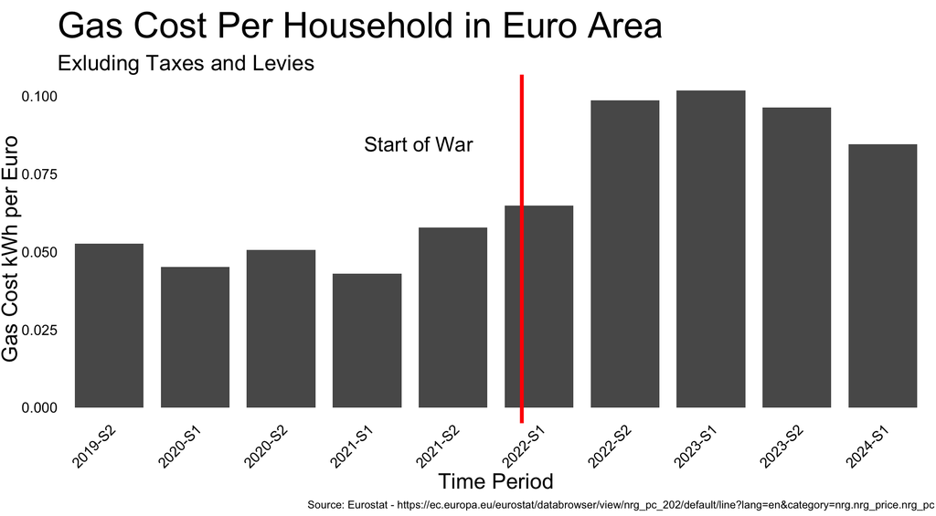

```r
data_path <- here("data_raw", "nrg_pc_202_page_linear.csv")
energy_prices <- read_csv(data_path) %>%
      janitor::clean_names()

euro_area <- energy_prices %>%
    filter(geo == "EA")

euro_area$color <- ifelse(euro_area$time_period == "2022-S1", "highlight", "normal")

ggplot(euro_area) +
    geom_bar(aes(x = time_period, y = obs_value),
             stat = "identity", width = 0.8, show.legend = FALSE) +
    labs(
        title = "Gas Cost Per Household in Euro Area",
        subtitle = "Exluding Taxes and Levies",
        x = "Time Period",
        y = "Gas Cost kWh per Euro",
        caption = "Source: Eurostat - https://ec.europa.eu/eurostat/databrowser/view/nrg_pc_202/default/line?lang=en&category=nrg.nrg_price.nrg_pc") +
    theme_void()+
    theme(
        plot.title = element_text(size = 20),
        plot.subtitle = element_text(size = 12),
        axis.text.x = element_text(angle = 45, hjust = 1, size = 8,
        vjust = 1),
        axis.title.y = element_text(angle = 90, hjust = 0.5,
        size = 12, vjust = 1),
        axis.title.x = element_text(size = 12),
        axis.text.y = element_text(size = 8),
        plot.margin = margin(1, 1, 3, 1),
        plot.caption = element_text(size = 6)
    ) +
    geom_vline(xintercept = 5.8, linetype = "solid", color = "red",
    size = 1) +
    annotate("text", x = 4.6, y =  .08,
             label = "Start of War", angle = 0, vjust = -0.5, size = 4)
```

Russia played a major role in the European energy market as a major exporter of natural gas. Energy sources from Russia was found throughout Europe, helping provide cheap energy. However with this cheap energy being removed there was huge jump in the price of gas, which is show on the graph. The cost per household nearly doubled after the war and maintained those levels for years afterwards.

##Imports

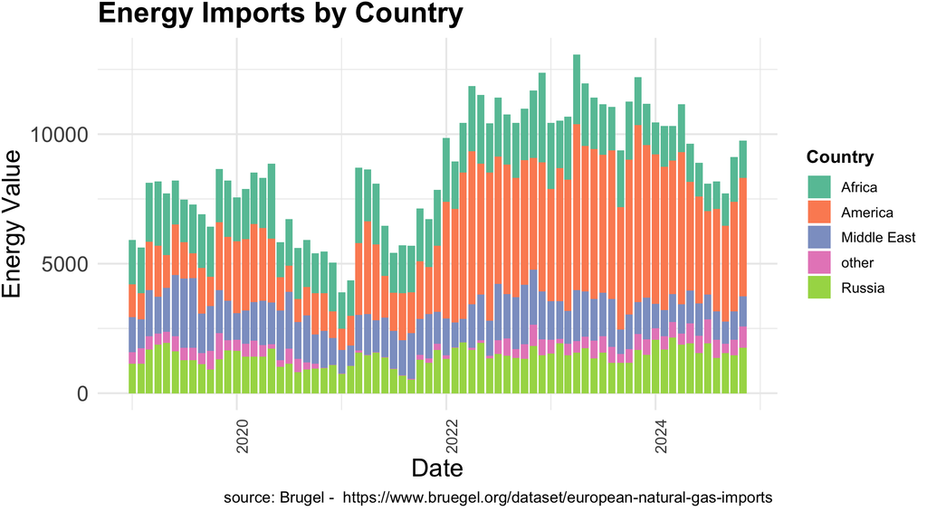

```r
route_data <- read_xlsx(here::here('data_raw', 'LNG plot data 2024-12-04.xlsx'))

energy_import <- route_data %>%
    select(-1) %>%
    janitor::clean_names()


long_import <- energy_import %>%
  pivot_longer(
    cols = -dates,
    names_to = "country",
    values_to = "value"
  )

long_import$dates <- as.Date(paste("01", long_import$dates, sep = "/"), format = "%d/%m/%Y")

ggplot(long_import, aes(x = dates, y = value, fill = country)) +
  geom_bar(stat = "identity") +
  theme_minimal() +
  labs(
    title = "Energy Imports by Country",
    caption = "source: Brugel -  https://www.bruegel.org/dataset/european-natural-gas-imports ",
    x = "Date",
    y = "Energy Value",
    fill = "Country"
  )+
  scale_fill_brewer(palette = "Set2",
                    labels = c("africa" = "Africa",
                               "middle_east" = "Middle East",
                               "america" = "America",
                                "russia" = "Russia")) +
  theme(
    axis.text.x = element_text(angle = 90, hjust = 1),
    plot.title = element_text(size = 16, face = "bold"),
    plot.subtitle = element_text(size = 12),
    axis.title.x = element_text(size = 14),
    axis.title.y = element_text(size = 14),
    axis.text.y = element_text(size = 12),
    plot.margin = margin(1, 1, 3, 1),
    legend.title = element_text(size = 10, face = "bold"),
    legend.text = element_text(size = 8),
    legend.key.size = unit(0.5, "cm"),
    legend.position = "right"
 )+
    guides(
    fill = guide_legend(title = "Country")
  )
```

##Domestic Production

```r
route_data <- read_csv(here::here('data_raw', 'monthly_full_release_long_format.csv'))

energy_source <- route_data %>%
    janitor::clean_names()

eu_energy_source <- energy_source %>%
    filter(category == "Electricity generation") %>%
    filter(area == "EU") %>%
    filter(subcategory != "Total") %>%
    filter(unit == "TWh") %>%
    filter(subcategory == "Fuel") %>%
    filter(variable != c("Demand","Clean"))


eu_total <- energy_source %>%
    filter(category == "Electricity generation") %>%
    filter(area == "EU") %>%
    filter(subcategory == "Total")

eu_total
```

```
#> # A tibble: 118 × 18
#>    area  country_code date       area_type continent ember_region    eu  oecd
#>    <chr> <chr>        <date>     <chr>     <chr>     <chr>        <dbl> <dbl>
#>  1 EU    <NA>         2015-01-01 Region    <NA>      <NA>            NA    NA
#>  2 EU    <NA>         2015-02-01 Region    <NA>      <NA>            NA    NA
#>  3 EU    <NA>         2015-03-01 Region    <NA>      <NA>            NA    NA
#>  4 EU    <NA>         2015-04-01 Region    <NA>      <NA>            NA    NA
#>  5 EU    <NA>         2015-05-01 Region    <NA>      <NA>            NA    NA
#>  6 EU    <NA>         2015-06-01 Region    <NA>      <NA>            NA    NA
#>  7 EU    <NA>         2015-07-01 Region    <NA>      <NA>            NA    NA
#>  8 EU    <NA>         2015-08-01 Region    <NA>      <NA>            NA    NA
#>  9 EU    <NA>         2015-09-01 Region    <NA>      <NA>            NA    NA
#> 10 EU    <NA>         2015-10-01 Region    <NA>      <NA>            NA    NA
#> # ℹ 108 more rows
#> # ℹ 10 more variables: g20 <dbl>, g7 <dbl>, asean <dbl>, category <chr>,
#> #   subcategory <chr>, variable <chr>, unit <chr>, value <dbl>,
#> #   yo_y_absolute_change <dbl>, yo_y_percent_change <dbl>
```

```r
total_prodution <- eu_total %>%
    ggplot(aes(x = date, y = value, color = variable))+
    geom_line() +
    theme_minimal() +
    labs(title = "Total EU Domestic Electriciy Generation By Type",
         x = "Date",
         y = "Terrawatt Hours (TWh)",
         caption = "Source: Ember") +
    scale_color_viridis(discrete = TRUE, option = "plasma") +
    theme(legend.position = "none")
```

[figure not shown]

```r
ani_plot <- eu_energy_source %>%
    ggplot(aes(x = date, y = value, color = variable)) +
    geom_line() +
    geom_point() +
    geom_text_repel( aes(label = variable),
    hjust = 0, nudge_x = 1, direction = "y",
    size = 3, max.overlaps = 20,segment.color = NA) +
    theme_minimal() +
    labs(title = "EU Domestic Electricity Generation By Type",
         subtitle = "Yellow represents Wind",
         x = "Date",
         y = "Terawatt Hours (TWh)",
         caption = "Source: Ember") +
    scale_color_viridis(discrete = TRUE, option = "plasma") +
    theme(legend.position = "none")

animated_plot <- ani_plot +
    transition_reveal(date) +  # Animate by the 'date' variable
    ease_aes('linear')

animate(animated_plot,
        end_pause = 15,
        duration = 10,
        renderer = magick_renderer())
```

```r
anim_save(here::here(
  'figs', 'animated_plot.gif'))

ggsave("total_prodution.png", path = "figs")
```

[output not shown]